# Project: Handwritten Digits Recognition Using Multilayer Perceptrons (MLPs)

## Course: Neural Network and Deep Learning

## MNIST Image Classification using MLP and CNN

### Name: Md Anwar Hossain

### Date: 19 May 2026

This project was completed as part of my Neural Network and Deep Learning course at Victoria University. **The Project instructions are given below:**

**Introduction:** Image classification is the most crucial domain in which neural networks play a significant role. The neural network accepts the input images and provides an output classification. In this project, develop an image classifier using basic neural networks with few different optimizers.

**Dataset:** The MNIST digits dataset provided by Yann Le Cun, is a well-known dataset for classification. It includes images with 255 pixels 28 x 28 greyscale and labelled with a number from 0 to 9, denoting the appropriate digit. There are 60,000 training images and 10,000 testing datasets.

Dataset can be import using keras API: https://keras.io/api/datasets/

**Task 1:** Import Libraries: a. Import required libraries (e.g., import tensorflow as tf)

**Task 2:** Import Dataset:

a. Load dataset using keras API.

b. Dataset must be pre-processed before training the network, if you check image in the training, you will see pixel value range from 0 to 255, scale these values range from 0 to 1. [note it is important that both training and testing dataset preprocessed same way].

**Task 3:** Build a Classifier using MLP

a. The layer is the most fundamental component of a neural network. Data is put into layers, and they extract representations from it. Choose the number of stacking layers so that model representations should, be useful for the given task.

**Task 4:** Compile the Model

A few more parameters are required before the model can be used for training. These are added at the build step of the model: Choose these parameters.

a. 1 Loss function

a. 2 Optimizer

a. 3 Metrics

**Task 5:** Train and Test the model.

a. Feed the training data to the built model.

b. Ask model to make predictions about a test set.

c. Verify that the predictions match the labels from the test labels.

# Task 1: Import Libraries

This section imports all required libraries for data handling, visualisation, neural network construction, evaluation and plotting.

```python
# ============================================================
# MNIST Image Classification using MLP and CNN
# ============================================================

# -----------------------------
# 1. Import required libraries
# -----------------------------
import os
import time
import random
import numpy as np
import pandas as pd
import matplotlib.pyplot as plt

import tensorflow as tf
from tensorflow import keras
from tensorflow.keras import layers, callbacks

from sklearn.model_selection import train_test_split
from sklearn.metrics import confusion_matrix, classification_report, ConfusionMatrixDisplay

# Reproducibility
SEED = 42
random.seed(SEED)
np.random.seed(SEED)
tf.random.set_seed(SEED)

print("TensorFlow version:", tf.__version__)
```

```
TensorFlow version: 2.20.0
```

# Task 2: Import and Preprocess Dataset

## Task 2a: Load and preprocess MNIST Dataset

```python
# -----------------------------
# 2. Load and preprocess MNIST
# -----------------------------
(x_train_full, y_train_full), (x_test, y_test) = keras.datasets.mnist.load_data()

print("Original training shape:", x_train_full.shape)
print("Original test shape:", x_test.shape)

# Scale pixel values from 0–255 to 0–1
x_train_full = x_train_full.astype("float32") / 255.0
x_test = x_test.astype("float32") / 255.0

# Fixed validation split for fair model comparison
x_train_img, x_val_img, y_train, y_val = train_test_split(
    x_train_full,
    y_train_full,
    test_size=0.10,
    random_state=SEED,
    stratify=y_train_full
)

# Flattened data for MLP
x_train_mlp = x_train_img.reshape(-1, 28 * 28)
x_val_mlp = x_val_img.reshape(-1, 28 * 28)
x_test_mlp = x_test.reshape(-1, 28 * 28)

# 4D image data for CNN
x_train_cnn = x_train_img.reshape(-1, 28, 28, 1)
x_val_cnn = x_val_img.reshape(-1, 28, 28, 1)
x_test_cnn = x_test.reshape(-1, 28, 28, 1)

print("MLP training shape:", x_train_mlp.shape)
print("CNN training shape:", x_train_cnn.shape)
```

```
Downloading data from https://storage.googleapis.com/tensorflow/tf-keras-datasets/mnist.npz
11490434/11490434 ━━━━━━━━━━━━━━━━━━━━ 0s 0us/step
Original training shape: (60000, 28, 28)
Original test shape: (10000, 28, 28)
MLP training shape: (54000, 784)
CNN training shape: (54000, 28, 28, 1)
```

## Task 2b: Visualise Sample Images

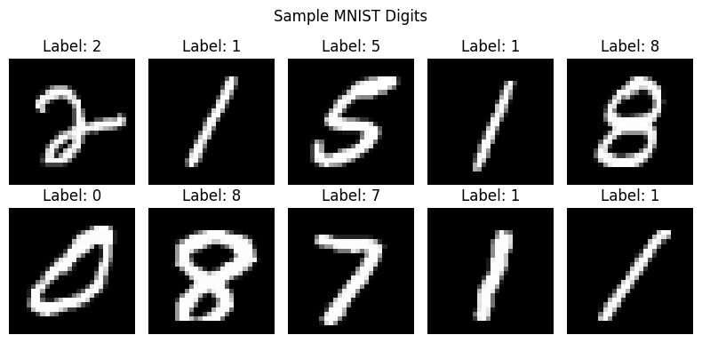

```python
# -----------------------------
# 3. Visualise sample digits
# -----------------------------
plt.figure(figsize=(8, 4))
for i in range(10):
    plt.subplot(2, 5, i + 1)
    plt.imshow(x_train_img[i], cmap="gray")
    plt.title(f"Label: {y_train[i]}")
    plt.axis("off")

plt.suptitle("Sample MNIST Digits")
plt.tight_layout()
plt.show()
```

# Task 3: Build Classifier using MLP

## Task 3.0: Make some helper functions.

```python
# -----------------------------
# 4. Helper functions
# -----------------------------

def get_callbacks(model_name):
    """
    Early stopping prevents unnecessary training after validation performance stops improving.
    ModelCheckpoint saves the best model separately for each architecture.
    """
    return [
        callbacks.EarlyStopping(
            monitor="val_loss",
            patience=3,
            restore_best_weights=True
        ),
        callbacks.ModelCheckpoint(
            filepath=f"{model_name}_best.keras",
            monitor="val_loss",
            save_best_only=True
        )
    ]


def plot_training_curves(history, title):
    """
    Plot accuracy and loss curves separately.
    """
    # Accuracy curve
    plt.figure(figsize=(7, 5))
    plt.plot(history.history["accuracy"], label="Training Accuracy")
    plt.plot(history.history["val_accuracy"], label="Validation Accuracy")
    plt.xlabel("Epoch")
    plt.ylabel("Accuracy")
    plt.title(f"{title}: Accuracy Curve")
    plt.legend()
    plt.grid(alpha=0.3)
    plt.show()

    # Loss curve
    plt.figure(figsize=(7, 5))
    plt.plot(history.history["loss"], label="Training Loss")
    plt.plot(history.history["val_loss"], label="Validation Loss")
    plt.xlabel("Epoch")
    plt.ylabel("Loss")
    plt.title(f"{title}: Loss Curve")
    plt.legend()
    plt.grid(alpha=0.3)
    plt.show()


def evaluate_model(model, x_test_data, y_test_data, model_name):
    """
    Evaluate model using test loss, test accuracy, confusion matrix and classification report.
    """
    test_loss, test_acc = model.evaluate(x_test_data, y_test_data, verbose=0)

    y_prob = model.predict(x_test_data, verbose=0)
    y_pred = np.argmax(y_prob, axis=1)

    print(f"\n===== {model_name} Evaluation =====")
    print(f"Test Loss: {test_loss:.4f}")
    print(f"Test Accuracy: {test_acc:.4f}")

    print("\nClassification Report:")
    print(classification_report(y_test_data, y_pred, digits=4))

    cm = confusion_matrix(y_test_data, y_pred)
    disp = ConfusionMatrixDisplay(confusion_matrix=cm)
    disp.plot(cmap="Blues", values_format="d")
    plt.title(f"{model_name}: Confusion Matrix")
    plt.show()

    return test_loss, test_acc, y_pred


def count_parameters(model):
    return model.count_params()
```

## Task 3a: Build Baseline MLP Model

A Multilayer Perceptron (MLP) model is constructed using fully connected dense layers with ReLU activation. Softmax activation is used in the output layer for multi-class classification.

```python
# -----------------------------
# 5. Build MLP (Multilayer Perceptron) models
# -----------------------------

def build_mlp_model(optimizer="adam", dropout=False, deeper=False):
    model = keras.Sequential()

    model.add(layers.Input(shape=(784,)))

    if deeper:
        model.add(layers.Dense(256, activation="relu"))
        if dropout:
            model.add(layers.Dropout(0.30))

        model.add(layers.Dense(128, activation="relu"))
        if dropout:
            model.add(layers.Dropout(0.30))

        model.add(layers.Dense(64, activation="relu"))

    else:
        model.add(layers.Dense(128, activation="relu"))
        if dropout:
            model.add(layers.Dropout(0.20))

        model.add(layers.Dense(64, activation="relu"))
        if dropout:
            model.add(layers.Dropout(0.20))

    model.add(layers.Dense(10, activation="softmax"))

    model.compile(
        optimizer=optimizer,
        loss="sparse_categorical_crossentropy",
        metrics=["accuracy"]
    )

    return model
```

# Task 4 and 5: Compile and train/test model

## Applied loss function defined above, used SGD, RMSPROP and ADAM optimizers, and calculate metrics

```
Training MLP with SGD optimizer...
1688/1688 ━━━━━━━━━━━━━━━━━━━━ 10s 4ms/step - accuracy: 0.8281 - loss: 0.6676 - val_accuracy: 0.9013 - val_loss: 0.3507
1688/1688 ━━━━━━━━━━━━━━━━━━━━ 4s 3ms/step - accuracy: 0.9133 - loss: 0.3030 - val_accuracy: 0.9193 - val_loss: 0.2834
1688/1688 ━━━━━━━━━━━━━━━━━━━━ 4s 2ms/step - accuracy: 0.9274 - loss: 0.2517 - val_accuracy: 0.9310 - val_loss: 0.2479
1688/1688 ━━━━━━━━━━━━━━━━━━━━ 5s 3ms/step - accuracy: 0.9366 - loss: 0.2190 - val_accuracy: 0.9382 - val_loss: 0.2232
1688/1688 ━━━━━━━━━━━━━━━━━━━━ 5s 3ms/step - accuracy: 0.9438 - loss: 0.1939 - val_accuracy: 0.9423 - val_loss: 0.2039
1688/1688 ━━━━━━━━━━━━━━━━━━━━ 5s 3ms/step - accuracy: 0.9496 - loss: 0.1738 - val_accuracy: 0.9467 - val_loss: 0.1881
1688/1688 ━━━━━━━━━━━━━━━━━━━━ 5s 3ms/step - accuracy: 0.9544 - loss: 0.1573 - val_accuracy: 0.9513 - val_loss: 0.1749
1688/1688 ━━━━━━━━━━━━━━━━━━━━ 7s 4ms/step - accuracy: 0.9580 - loss: 0.1435 - val_accuracy: 0.9545 - val_loss: 0.1641
1688/1688 ━━━━━━━━━━━━━━━━━━━━ 8s 3ms/step - accuracy: 0.9616 - loss: 0.1318 - val_accuracy: 0.9565 - val_loss: 0.1551
1688/1688 ━━━━━━━━━━━━━━━━━━━━ 8s 5ms/step - accuracy: 0.9644 - loss: 0.1218 - val_accuracy: 0.9590 - val_loss: 0.1475
1688/1688 ━━━━━━━━━━━━━━━━━━━━ 6s 3ms/step - accuracy: 0.9677 - loss: 0.1130 - val_accuracy: 0.9605 - val_loss: 0.1410
1688/1688 ━━━━━━━━━━━━━━━━━━━━ 7s 4ms/step - accuracy: 0.9698 - loss: 0.1053 - val_accuracy: 0.9628 - val_loss: 0.1355
1688/1688 ━━━━━━━━━━━━━━━━━━━━ 7s 4ms/step - accuracy: 0.9722 - loss: 0.0985 - val_accuracy: 0.9642 - val_loss: 0.1305
1688/1688 ━━━━━━━━━━━━━━━━━━━━ 8s 3ms/step - accuracy: 0.9741 - loss: 0.0924 - val_accuracy: 0.9660 - val_loss: 0.1261
1688/1688 ━━━━━━━━━━━━━━━━━━━━ 6s 4ms/step - accuracy: 0.9762 - loss: 0.0869 - val_accuracy: 0.9670 - val_loss: 0.1221
1688/1688 ━━━━━━━━━━━━━━━━━━━━ 6s 3ms/step - accuracy: 0.9775 - loss: 0.0819 - val_accuracy: 0.9677 - val_loss: 0.1187
1688/1688 ━━━━━━━━━━━━━━━━━━━━ 6s 3ms/step - accuracy: 0.9787 - loss: 0.0773 - val_accuracy: 0.9685 - val_loss: 0.1156
1688/1688 ━━━━━━━━━━━━━━━━━━━━ 9s 3ms/step - accuracy: 0.9798 - loss: 0.0731 - val_accuracy: 0.9690 - val_loss: 0.1127
1688/1688 ━━━━━━━━━━━━━━━━━━━━ 8s 5ms/step - accuracy: 0.9809 - loss: 0.0692 - val_accuracy: 0.9692 - val_loss: 0.1102
1688/1688 ━━━━━━━━━━━━━━━━━━━━ 5s 3ms/step - accuracy: 0.9818 - loss: 0.0656 - val_accuracy: 0.9697 - val_loss: 0.1079

===== MLP (SGD) Evaluation =====
Test Loss: 0.0946
Test Accuracy: 0.9704

Classification Report:
              precision    recall  f1-score   support

           0     0.9710    0.9908    0.9808       980
           1     0.9885    0.9868    0.9877      1135
           2     0.9647    0.9797    0.9721      1032
           3     0.9636    0.9693    0.9664      1010
           4     0.9608    0.9735    0.9671       982
           5     0.9736    0.9518    0.9626       892
           6     0.9728    0.9697    0.9712       958
           7     0.9670    0.9698    0.9684      1028
           8     0.9603    0.9682    0.9642       974
           9     0.9804    0.9405    0.9600      1009

    accuracy                         0.9704     10000
   macro avg     0.9703    0.9700    0.9701     10000
weighted avg     0.9705    0.9704    0.9704     10000
```

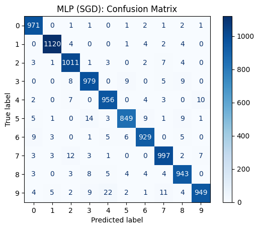

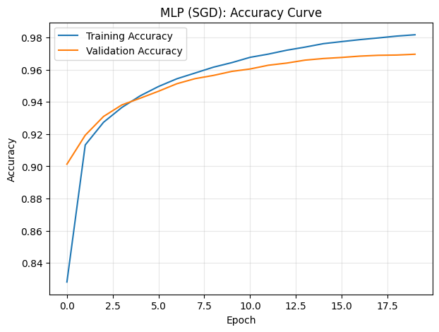

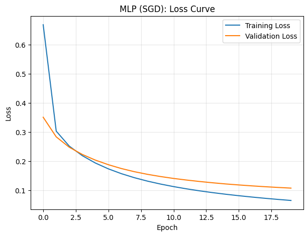

```
Training MLP with RMSPROP optimizer...
1688/1688 ━━━━━━━━━━━━━━━━━━━━ 13s 6ms/step - accuracy: 0.9276 - loss: 0.2445 - val_accuracy: 0.9552 - val_loss: 0.1471
1688/1688 ━━━━━━━━━━━━━━━━━━━━ 15s 3ms/step - accuracy: 0.9670 - loss: 0.1096 - val_accuracy: 0.9643 - val_loss: 0.1241
1688/1688 ━━━━━━━━━━━━━━━━━━━━ 5s 3ms/step - accuracy: 0.9770 - loss: 0.0781 - val_accuracy: 0.9685 - val_loss: 0.1153
1688/1688 ━━━━━━━━━━━━━━━━━━━━ 7s 4ms/step - accuracy: 0.9824 - loss: 0.0602 - val_accuracy: 0.9668 - val_loss: 0.1347
1688/1688 ━━━━━━━━━━━━━━━━━━━━ 5s 3ms/step - accuracy: 0.9861 - loss: 0.0483 - val_accuracy: 0.9693 - val_loss: 0.1396
1688/1688 ━━━━━━━━━━━━━━━━━━━━ 5s 3ms/step - accuracy: 0.9894 - loss: 0.0393 - val_accuracy: 0.9712 - val_loss: 0.1555

===== MLP (RMSPROP) Evaluation =====
Test Loss: 0.0960
Test Accuracy: 0.9735

Classification Report:
              precision    recall  f1-score   support

           0     0.9567    0.9918    0.9739       980
           1     0.9885    0.9885    0.9885      1135
           2     0.9693    0.9797    0.9745      1032
           3     0.9714    0.9762    0.9738      1010
           4     0.9806    0.9796    0.9801       982
           5     0.9751    0.9675    0.9713       892
           6     0.9652    0.9833    0.9741       958
           7     0.9764    0.9669    0.9717      1028
           8     0.9675    0.9466    0.9569       974
           9     0.9826    0.9524    0.9673      1009

    accuracy                         0.9735     10000
   macro avg     0.9733    0.9733    0.9732     10000
weighted avg     0.9736    0.9735    0.9735     10000
```

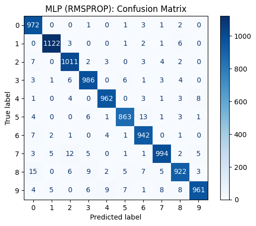

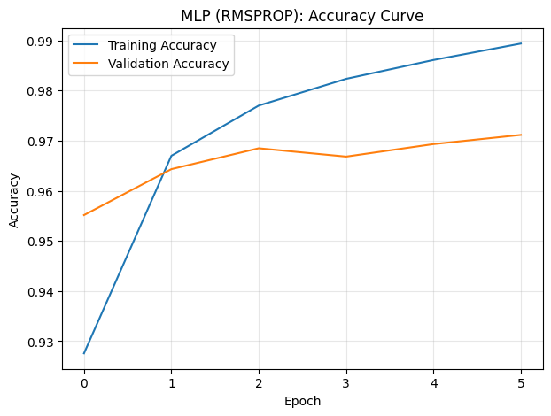

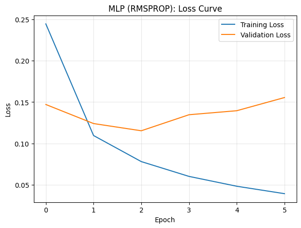

```
Training MLP with ADAM optimizer...
1688/1688 ━━━━━━━━━━━━━━━━━━━━ 8s 4ms/step - accuracy: 0.9259 - loss: 0.2498 - val_accuracy: 0.9583 - val_loss: 0.1474
1688/1688 ━━━━━━━━━━━━━━━━━━━━ 6s 3ms/step - accuracy: 0.9675 - loss: 0.1046 - val_accuracy: 0.9653 - val_loss: 0.1133
1688/1688 ━━━━━━━━━━━━━━━━━━━━ 5s 3ms/step - accuracy: 0.9783 - loss: 0.0700 - val_accuracy: 0.9720 - val_loss: 0.0985
1688/1688 ━━━━━━━━━━━━━━━━━━━━ 5s 3ms/step - accuracy: 0.9844 - loss: 0.0501 - val_accuracy: 0.9743 - val_loss: 0.0968
1688/1688 ━━━━━━━━━━━━━━━━━━━━ 5s 3ms/step - accuracy: 0.9879 - loss: 0.0385 - val_accuracy: 0.9713 - val_loss: 0.1121
1688/1688 ━━━━━━━━━━━━━━━━━━━━ 5s 3ms/step - accuracy: 0.9902 - loss: 0.0304 - val_accuracy: 0.9725 - val_loss: 0.1161
1688/1688 ━━━━━━━━━━━━━━━━━━━━ 6s 3ms/step - accuracy: 0.9921 - loss: 0.0244 - val_accuracy: 0.9728 - val_loss: 0.1177

===== MLP (ADAM) Evaluation =====
Test Loss: 0.0849
Test Accuracy: 0.9767

Classification Report:
              precision    recall  f1-score   support

           0     0.9749    0.9898    0.9823       980
           1     0.9920    0.9859    0.9890      1135
           2     0.9638    0.9816    0.9726      1032
           3     0.9631    0.9812    0.9720      1010
           4     0.9806    0.9786    0.9796       982
           5     0.9797    0.9731    0.9764       892
           6     0.9873    0.9770    0.9822       958
           7     0.9813    0.9718    0.9765      1028
           8     0.9596    0.9754    0.9674       974
           9     0.9846    0.9514    0.9677      1009

    accuracy                         0.9767     10000
   macro avg     0.9767    0.9766    0.9766     10000
weighted avg     0.9768    0.9767    0.9767     10000
```

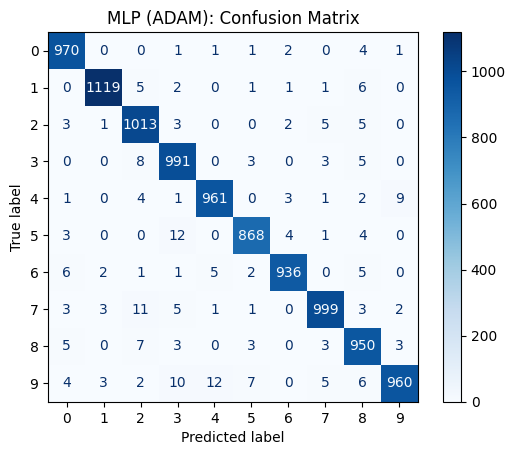

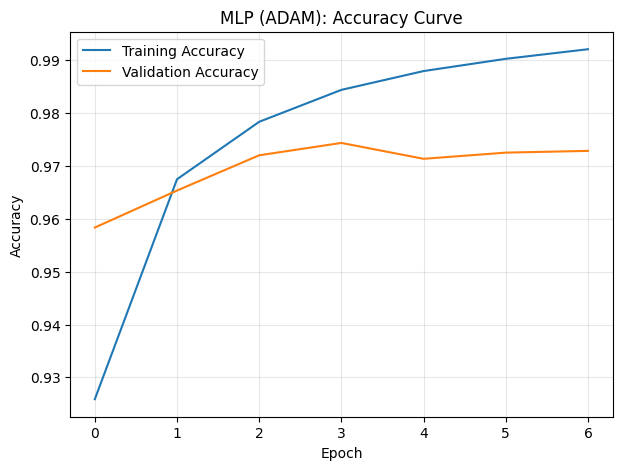

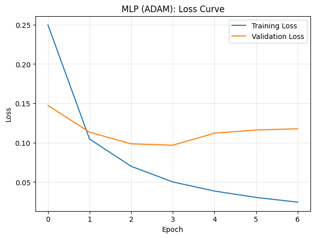

```python
# -----------------------------
# 6. Optimizer comparison using same MLP architecture
# -----------------------------

# sgd: Stochastic Gradient Descent
# rmsprop: Room Mean Square Propagation
# adam: Adaptive Moment Estimation

optimizers = ["sgd", "rmsprop", "adam"]
optimizer_results = []
optimizer_histories = {}

for opt in optimizers:
    print(f"\nTraining MLP with {opt.upper()} optimizer...")

    model = build_mlp_model(optimizer=opt, dropout=False, deeper=False)

    start_time = time.time()

    history = model.fit(
        x_train_mlp,
        y_train,
        validation_data=(x_val_mlp, y_val),
        epochs=20,
        batch_size=32,
        callbacks=get_callbacks(f"mlp_{opt}"),
        verbose=1
    )

    training_time = time.time() - start_time

    test_loss, test_acc, _ = evaluate_model(
        model,
        x_test_mlp,
        y_test,
        f"MLP ({opt.upper()})"
    )

    best_val_acc = max(history.history["val_accuracy"])
    best_val_loss = min(history.history["val_loss"])
    final_train_acc = history.history["accuracy"][-1]
    final_val_acc = history.history["val_accuracy"][-1]

    optimizer_results.append({
        "Model": f"MLP ({opt.upper()})",
        "Optimizer": opt,
        "Parameters": count_parameters(model),
        "Best Validation Accuracy": best_val_acc,
        "Best Validation Loss": best_val_loss,
        "Test Accuracy": test_acc,
        "Test Loss": test_loss,
        "Overfitting Gap": final_train_acc - final_val_acc,
        "Training Time (sec)": training_time
    })

    optimizer_histories[opt] = history

    plot_training_curves(history, f"MLP ({opt.upper()})")
```

## Task 5 (continued): Apply dropout and evaluate model

```
Training MLP with Dropout...
1688/1688 ━━━━━━━━━━━━━━━━━━━━ 10s 4ms/step - accuracy: 0.8959 - loss: 0.3417 - val_accuracy: 0.9523 - val_loss: 0.1625
1688/1688 ━━━━━━━━━━━━━━━━━━━━ 5s 3ms/step - accuracy: 0.9511 - loss: 0.1682 - val_accuracy: 0.9595 - val_loss: 0.1307
1688/1688 ━━━━━━━━━━━━━━━━━━━━ 5s 3ms/step - accuracy: 0.9603 - loss: 0.1298 - val_accuracy: 0.9682 - val_loss: 0.1138
1688/1688 ━━━━━━━━━━━━━━━━━━━━ 4s 3ms/step - accuracy: 0.9669 - loss: 0.1084 - val_accuracy: 0.9707 - val_loss: 0.1007
1688/1688 ━━━━━━━━━━━━━━━━━━━━ 5s 3ms/step - accuracy: 0.9700 - loss: 0.0965 - val_accuracy: 0.9698 - val_loss: 0.0986
1688/1688 ━━━━━━━━━━━━━━━━━━━━ 4s 3ms/step - accuracy: 0.9736 - loss: 0.0842 - val_accuracy: 0.9735 - val_loss: 0.0914
1688/1688 ━━━━━━━━━━━━━━━━━━━━ 4s 3ms/step - accuracy: 0.9753 - loss: 0.0792 - val_accuracy: 0.9725 - val_loss: 0.0984
1688/1688 ━━━━━━━━━━━━━━━━━━━━ 5s 3ms/step - accuracy: 0.9783 - loss: 0.0708 - val_accuracy: 0.9778 - val_loss: 0.0824
1688/1688 ━━━━━━━━━━━━━━━━━━━━ 4s 3ms/step - accuracy: 0.9788 - loss: 0.0649 - val_accuracy: 0.9772 - val_loss: 0.0808
1688/1688 ━━━━━━━━━━━━━━━━━━━━ 5s 3ms/step - accuracy: 0.9804 - loss: 0.0617 - val_accuracy: 0.9773 - val_loss: 0.0850
1688/1688 ━━━━━━━━━━━━━━━━━━━━ 4s 3ms/step - accuracy: 0.9814 - loss: 0.0591 - val_accuracy: 0.9775 - val_loss: 0.0914
1688/1688 ━━━━━━━━━━━━━━━━━━━━ 5s 3ms/step - accuracy: 0.9814 - loss: 0.0574 - val_accuracy: 0.9773 - val_loss: 0.0860

===== MLP with Dropout Evaluation =====
Test Loss: 0.0754
Test Accuracy: 0.9793

Classification Report:
              precision    recall  f1-score   support

           0     0.9798    0.9898    0.9848       980
           1     0.9912    0.9921    0.9916      1135
           2     0.9722    0.9845    0.9783      1032
           3     0.9733    0.9743    0.9738      1010
           4     0.9767    0.9807    0.9787       982
           5     0.9920    0.9731    0.9825       892
           6     0.9833    0.9854    0.9844       958
           7     0.9757    0.9757    0.9757      1028
           8     0.9723    0.9743    0.9733       974
           9     0.9768    0.9613    0.9690      1009

    accuracy                         0.9793     10000
   macro avg     0.9793    0.9791    0.9792     10000
weighted avg     0.9793    0.9793    0.9793     10000
```

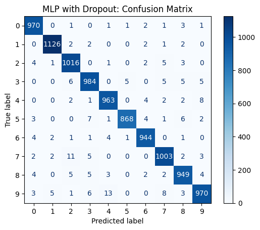

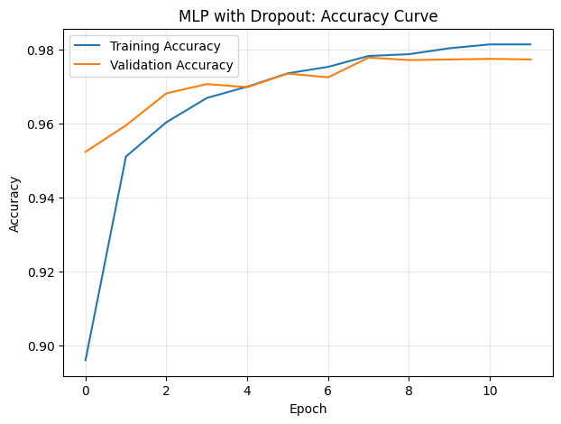

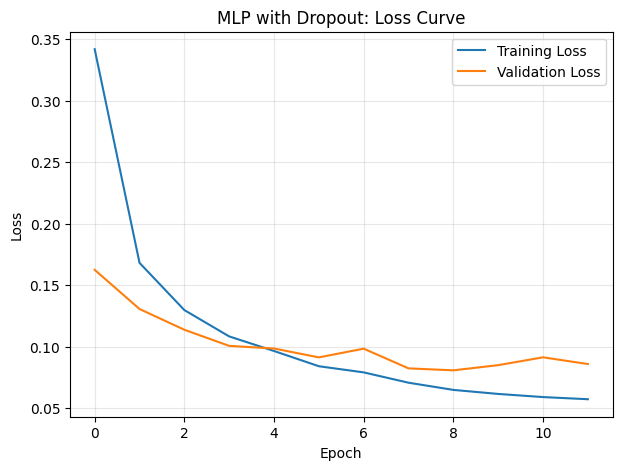

```python
# -----------------------------
# 7. Dropout MLP
# -----------------------------

print("\nTraining MLP with Dropout...")

mlp_dropout = build_mlp_model(
    optimizer="adam",
    dropout=True,
    deeper=False
)

start_time = time.time()

history_dropout = mlp_dropout.fit(
    x_train_mlp,
    y_train,
    validation_data=(x_val_mlp, y_val),
    epochs=20,
    batch_size=32,
    callbacks=get_callbacks("mlp_dropout"),
    verbose=1
)

dropout_time = time.time() - start_time

dropout_test_loss, dropout_test_acc, _ = evaluate_model(
    mlp_dropout,
    x_test_mlp,
    y_test,
    "MLP with Dropout"
)

plot_training_curves(history_dropout, "MLP with Dropout")
```

## Task 5 (continued): Build Deep MLP Model

A deeper neural network is developed by adding additional hidden layers to improve representation learning.

```
Training Deeper MLP...
1688/1688 ━━━━━━━━━━━━━━━━━━━━ 9s 4ms/step - accuracy: 0.9317 - loss: 0.2245 - val_accuracy: 0.9592 - val_loss: 0.1329
1688/1688 ━━━━━━━━━━━━━━━━━━━━ 5s 3ms/step - accuracy: 0.9719 - loss: 0.0926 - val_accuracy: 0.9690 - val_loss: 0.1087
1688/1688 ━━━━━━━━━━━━━━━━━━━━ 7s 4ms/step - accuracy: 0.9806 - loss: 0.0616 - val_accuracy: 0.9713 - val_loss: 0.1183
1688/1688 ━━━━━━━━━━━━━━━━━━━━ 8s 3ms/step - accuracy: 0.9838 - loss: 0.0491 - val_accuracy: 0.9633 - val_loss: 0.1572
1688/1688 ━━━━━━━━━━━━━━━━━━━━ 5s 3ms/step - accuracy: 0.9871 - loss: 0.0392 - val_accuracy: 0.9725 - val_loss: 0.1119

===== Deep MLP Evaluation =====
Test Loss: 0.0868
Test Accuracy: 0.9739

Classification Report:
              precision    recall  f1-score   support

           0     0.9729    0.9908    0.9818       980
           1     0.9894    0.9859    0.9876      1135
           2     0.9638    0.9806    0.9721      1032
           3     0.9695    0.9743    0.9719      1010
           4     0.9916    0.9674    0.9794       982
           5     0.9752    0.9697    0.9725       892
           6     0.9604    0.9885    0.9743       958
           7     0.9819    0.9514    0.9664      1028
           8     0.9481    0.9754    0.9615       974
           9     0.9857    0.9544    0.9698      1009

    accuracy                         0.9739     10000
   macro avg     0.9739    0.9738    0.9737     10000
weighted avg     0.9741    0.9739    0.9739     10000
```

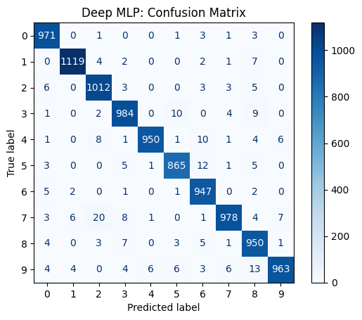

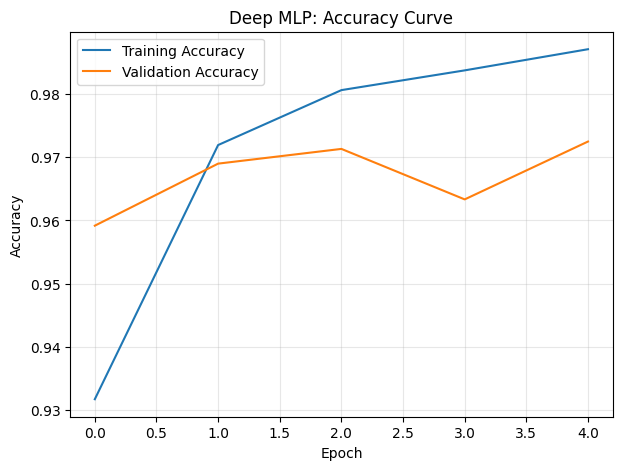

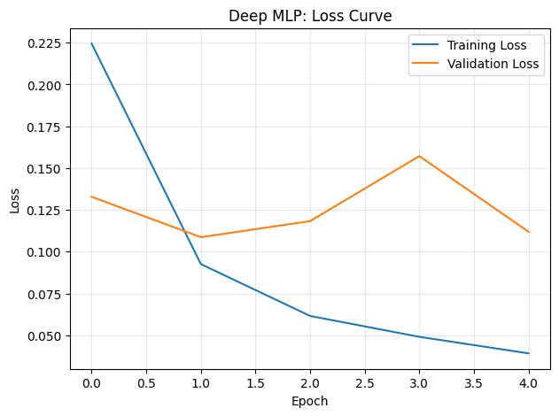

```python
# -----------------------------
# 8. Deeper MLP
# -----------------------------

print("\nTraining Deeper MLP...")

deep_mlp = build_mlp_model(
    optimizer="adam",
    dropout=False,
    deeper=True
)

start_time = time.time()

history_deep = deep_mlp.fit(
    x_train_mlp,
    y_train,
    validation_data=(x_val_mlp, y_val),
    epochs=20,
    batch_size=32,
    callbacks=get_callbacks("deep_mlp"),
    verbose=1
)

deep_time = time.time() - start_time

deep_test_loss, deep_test_acc, _ = evaluate_model(
    deep_mlp,
    x_test_mlp,
    y_test,
    "Deep MLP"
)

plot_training_curves(history_deep, "Deep MLP")
```

## CNN Extension Model

A Convolutional Neural Network (CNN) is additionally implemented to compare performance with MLP architectures. CNNs preserve spatial image structure and are widely used for image classification tasks.

```
Training CNN extension model...
```

```
Model: "sequential_5"
```

```
┏━━━━━━━━━━━━━━━━━━━━━━━━━━━━━━━━━┳━━━━━━━━━━━━━━━━━━━━━━━━┳━━━━━━━━━━━━━━━┓
┃ Layer (type)                    ┃ Output Shape           ┃       Param # ┃
┡━━━━━━━━━━━━━━━━━━━━━━━━━━━━━━━━━╇━━━━━━━━━━━━━━━━━━━━━━━━╇━━━━━━━━━━━━━━━┩
│ conv2d (Conv2D)                 │ (None, 26, 26, 32)     │           320 │
├─────────────────────────────────┼────────────────────────┼───────────────┤
│ max_pooling2d (MaxPooling2D)    │ (None, 13, 13, 32)     │             0 │
├─────────────────────────────────┼────────────────────────┼───────────────┤
│ conv2d_1 (Conv2D)               │ (None, 11, 11, 64)     │        18,496 │
├─────────────────────────────────┼────────────────────────┼───────────────┤
│ max_pooling2d_1 (MaxPooling2D)  │ (None, 5, 5, 64)       │             0 │
├─────────────────────────────────┼────────────────────────┼───────────────┤
│ flatten (Flatten)               │ (None, 1600)           │             0 │
├─────────────────────────────────┼────────────────────────┼───────────────┤
│ dense_16 (Dense)                │ (None, 64)             │       102,464 │
├─────────────────────────────────┼────────────────────────┼───────────────┤
│ dropout_2 (Dropout)             │ (None, 64)             │             0 │
├─────────────────────────────────┼────────────────────────┼───────────────┤
│ dense_17 (Dense)                │ (None, 10)             │           650 │
└─────────────────────────────────┴────────────────────────┴───────────────┘
```

```
 Total params: 121,930 (476.29 KB)
```

```
 Trainable params: 121,930 (476.29 KB)
```

```
 Non-trainable params: 0 (0.00 B)
```

```
1688/1688 ━━━━━━━━━━━━━━━━━━━━ 13s 5ms/step - accuracy: 0.8985 - loss: 0.3258 - val_accuracy: 0.9780 - val_loss: 0.0790
1688/1688 ━━━━━━━━━━━━━━━━━━━━ 6s 3ms/step - accuracy: 0.9622 - loss: 0.1271 - val_accuracy: 0.9840 - val_loss: 0.0595
1688/1688 ━━━━━━━━━━━━━━━━━━━━ 6s 4ms/step - accuracy: 0.9715 - loss: 0.0953 - val_accuracy: 0.9848 - val_loss: 0.0632
1688/1688 ━━━━━━━━━━━━━━━━━━━━ 6s 3ms/step - accuracy: 0.9774 - loss: 0.0758 - val_accuracy: 0.9865 - val_loss: 0.0511
1688/1688 ━━━━━━━━━━━━━━━━━━━━ 6s 4ms/step - accuracy: 0.9801 - loss: 0.0661 - val_accuracy: 0.9878 - val_loss: 0.0531
1688/1688 ━━━━━━━━━━━━━━━━━━━━ 6s 3ms/step - accuracy: 0.9819 - loss: 0.0574 - val_accuracy: 0.9887 - val_loss: 0.0454
1688/1688 ━━━━━━━━━━━━━━━━━━━━ 6s 4ms/step - accuracy: 0.9833 - loss: 0.0538 - val_accuracy: 0.9898 - val_loss: 0.0413
1688/1688 ━━━━━━━━━━━━━━━━━━━━ 6s 3ms/step - accuracy: 0.9845 - loss: 0.0469 - val_accuracy: 0.9905 - val_loss: 0.0431
1688/1688 ━━━━━━━━━━━━━━━━━━━━ 6s 4ms/step - accuracy: 0.9856 - loss: 0.0433 - val_accuracy: 0.9897 - val_loss: 0.0477
1688/1688 ━━━━━━━━━━━━━━━━━━━━ 6s 3ms/step - accuracy: 0.9872 - loss: 0.0394 - val_accuracy: 0.9897 - val_loss: 0.0414

===== CNN Extension Evaluation =====
Test Loss: 0.0281
Test Accuracy: 0.9906

Classification Report:
              precision    recall  f1-score   support

           0     0.9939    0.9939    0.9939       980
           1     0.9947    0.9947    0.9947      1135
           2     0.9894    0.9952    0.9923      1032
           3     0.9990    0.9842    0.9915      1010
           4     0.9909    0.9969    0.9939       982
           5     0.9769    0.9955    0.9861       892
           6     0.9958    0.9875    0.9916       958
           7     0.9836    0.9893    0.9864      1028
           8     0.9887    0.9897    0.9892       974
           9     0.9920    0.9792    0.9855      1009

    accuracy                         0.9906     10000
   macro avg     0.9905    0.9906    0.9905     10000
weighted avg     0.9906    0.9906    0.9906     10000
```

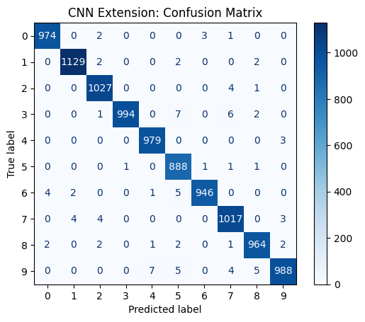

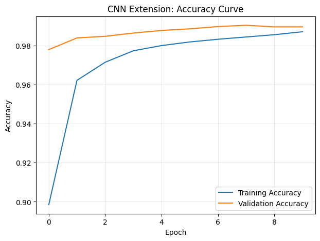

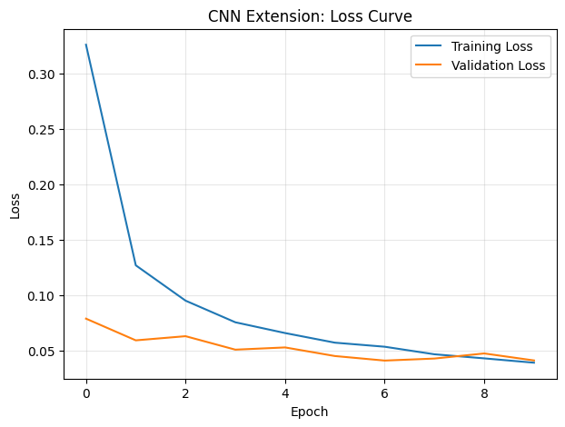

```python
# -----------------------------
# 9. CNN (Convoluted Neural Network) extension model
# -----------------------------

def build_cnn_model():
    model = keras.Sequential([
        layers.Input(shape=(28, 28, 1)),

        layers.Conv2D(32, kernel_size=(3, 3), activation="relu"),
        layers.MaxPooling2D(pool_size=(2, 2)),

        layers.Conv2D(64, kernel_size=(3, 3), activation="relu"),
        layers.MaxPooling2D(pool_size=(2, 2)),

        layers.Flatten(),

        layers.Dense(64, activation="relu"),
        layers.Dropout(0.50),

        layers.Dense(10, activation="softmax")
    ])

    model.compile(
        optimizer="adam",
        loss="sparse_categorical_crossentropy",
        metrics=["accuracy"]
    )

    return model


print("\nTraining CNN extension model...")

cnn_model = build_cnn_model()
cnn_model.summary()

start_time = time.time()

history_cnn = cnn_model.fit(
    x_train_cnn,
    y_train,
    validation_data=(x_val_cnn, y_val),
    epochs=20,
    batch_size=32,
    callbacks=get_callbacks("cnn_model"),
    verbose=1
)

cnn_time = time.time() - start_time

cnn_test_loss, cnn_test_acc, _ = evaluate_model(
    cnn_model,
    x_test_cnn,
    y_test,
    "CNN Extension"
)

plot_training_curves(history_cnn, "CNN Extension")
```

## Task 5 (continued): Create final comparison table of fitted models

```python
# -----------------------------
# 10. Create final comparison table
# -----------------------------

all_results = pd.DataFrame(optimizer_results)

extra_results = pd.DataFrame([
    {
        "Model": "MLP with Dropout",
        "Optimizer": "adam",
        "Parameters": count_parameters(mlp_dropout),
        "Best Validation Accuracy": max(history_dropout.history["val_accuracy"]),
        "Best Validation Loss": min(history_dropout.history["val_loss"]),
        "Test Accuracy": dropout_test_acc,
        "Test Loss": dropout_test_loss,
        "Overfitting Gap": history_dropout.history["accuracy"][-1] - history_dropout.history["val_accuracy"][-1],
        "Training Time (sec)": dropout_time
    },
    {
        "Model": "Deep MLP",
        "Optimizer": "adam",
        "Parameters": count_parameters(deep_mlp),
        "Best Validation Accuracy": max(history_deep.history["val_accuracy"]),
        "Best Validation Loss": min(history_deep.history["val_loss"]),
        "Test Accuracy": deep_test_acc,
        "Test Loss": deep_test_loss,
        "Overfitting Gap": history_deep.history["accuracy"][-1] - history_deep.history["val_accuracy"][-1],
        "Training Time (sec)": deep_time
    },
    {
        "Model": "CNN Extension",
        "Optimizer": "adam",
        "Parameters": count_parameters(cnn_model),
        "Best Validation Accuracy": max(history_cnn.history["val_accuracy"]),
        "Best Validation Loss": min(history_cnn.history["val_loss"]),
        "Test Accuracy": cnn_test_acc,
        "Test Loss": cnn_test_loss,
        "Overfitting Gap": history_cnn.history["accuracy"][-1] - history_cnn.history["val_accuracy"][-1],
        "Training Time (sec)": cnn_time
    }
])

final_results = pd.concat([all_results, extra_results], ignore_index=True)

final_results = final_results.sort_values(
    by="Test Accuracy",
    ascending=False
).reset_index(drop=True)

final_results
```

|  | Model | Optimizer | Parameters | Best Validation Accuracy | Best Validation Loss | Test Accuracy | Test Loss | Overfitting Gap | Training Time (sec) |
| --- | --- | --- | --- | --- | --- | --- | --- | --- | --- |
| 0 | CNN Extension | adam | 121930 | 0.990500 | 0.041269 | 0.9906 | 0.028141 | -0.002500 | 68.094050 |
| 1 | MLP with Dropout | adam | 109386 | 0.977833 | 0.080836 | 0.9793 | 0.075376 | 0.004074 | 63.686672 |
| 2 | MLP (ADAM) | adam | 109386 | 0.974333 | 0.096804 | 0.9767 | 0.084943 | 0.019222 | 40.626769 |
| 3 | Deep MLP | adam | 242762 | 0.972500 | 0.108676 | 0.9739 | 0.086820 | 0.014630 | 34.519297 |
| 4 | MLP (RMSPROP) | rmsprop | 109386 | 0.971167 | 0.115350 | 0.9735 | 0.095961 | 0.018222 | 49.017483 |
| 5 | MLP (SGD) | sgd | 109386 | 0.969667 | 0.107883 | 0.9704 | 0.094605 | 0.012093 | 128.231139 |

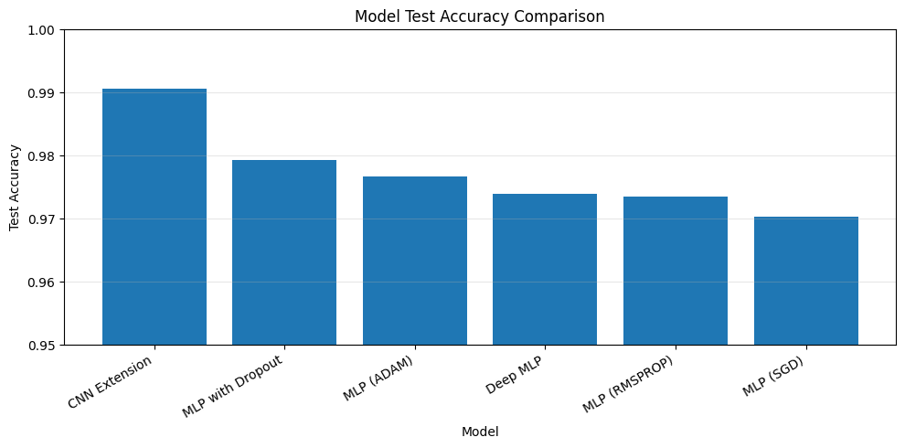

```python
# -----------------------------
# 11. Bar plot: test accuracy comparison
# -----------------------------

plt.figure(figsize=(10, 5))
plt.bar(final_results["Model"], final_results["Test Accuracy"])
plt.xlabel("Model")
plt.ylabel("Test Accuracy")
plt.title("Model Test Accuracy Comparison")
plt.xticks(rotation=30, ha="right")
plt.ylim(0.95, 1.00)
plt.grid(axis="y", alpha=0.3)
plt.tight_layout()
plt.show()
```

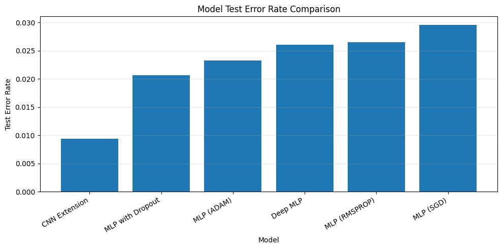

```python
# -----------------------------
# 12. Bar plot: test error rate comparison
# -----------------------------

final_results["Test Error Rate"] = 1 - final_results["Test Accuracy"]

plt.figure(figsize=(10, 5))
plt.bar(final_results["Model"], final_results["Test Error Rate"])
plt.xlabel("Model")
plt.ylabel("Test Error Rate")
plt.title("Model Test Error Rate Comparison")
plt.xticks(rotation=30, ha="right")
plt.grid(axis="y", alpha=0.3)
plt.tight_layout()
plt.show()
```

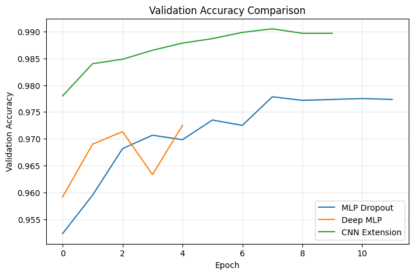

```python
# -----------------------------
# 13. Validation accuracy comparison: main models
# -----------------------------

plt.figure(figsize=(8, 5))
plt.plot(history_dropout.history["val_accuracy"], label="MLP Dropout")
plt.plot(history_deep.history["val_accuracy"], label="Deep MLP")
plt.plot(history_cnn.history["val_accuracy"], label="CNN Extension")
plt.xlabel("Epoch")
plt.ylabel("Validation Accuracy")
plt.title("Validation Accuracy Comparison")
plt.legend()
plt.grid(alpha=0.3)
plt.show()
```

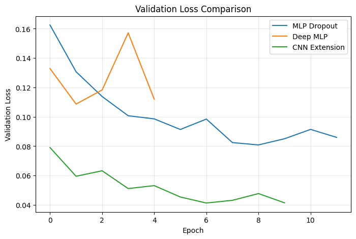

```python
# -----------------------------
# 14. Validation loss comparison: main models
# -----------------------------

plt.figure(figsize=(8, 5))
plt.plot(history_dropout.history["val_loss"], label="MLP Dropout")
plt.plot(history_deep.history["val_loss"], label="Deep MLP")
plt.plot(history_cnn.history["val_loss"], label="CNN Extension")
plt.xlabel("Epoch")
plt.ylabel("Validation Loss")
plt.title("Validation Loss Comparison")
plt.legend()
plt.grid(alpha=0.3)
plt.show()
```

## Task 5(b, c): Predict and verify best model.

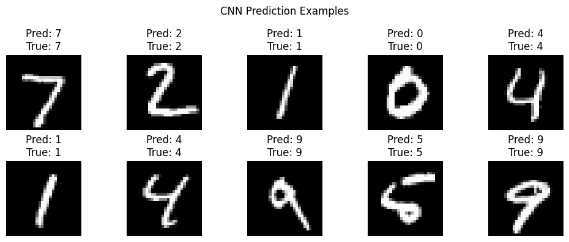

```python
# -----------------------------
# 15. Prediction examples
# -----------------------------

best_model = cnn_model
predictions = best_model.predict(x_test_cnn[:10], verbose=0)
predicted_labels = np.argmax(predictions, axis=1)

plt.figure(figsize=(10, 4))
for i in range(10):
    plt.subplot(2, 5, i + 1)
    plt.imshow(x_test[i], cmap="gray")
    plt.title(f"Pred: {predicted_labels[i]}\nTrue: {y_test[i]}")
    plt.axis("off")

plt.suptitle("CNN Prediction Examples")
plt.tight_layout()
plt.show()
```

```python
# -----------------------------
# 16. Save final results table
# -----------------------------

final_results.to_csv("mnist_model_comparison_results.csv", index=False)
print("Results saved as mnist_model_comparison_results.csv")

final_results
```

```
Results saved as mnist_model_comparison_results.csv
```

|  | Model | Optimizer | Parameters | Best Validation Accuracy | Best Validation Loss | Test Accuracy | Test Loss | Overfitting Gap | Training Time (sec) | Test Error Rate |
| --- | --- | --- | --- | --- | --- | --- | --- | --- | --- | --- |
| 0 | CNN Extension | adam | 121930 | 0.990500 | 0.041269 | 0.9906 | 0.028141 | -0.002500 | 68.094050 | 0.0094 |
| 1 | MLP with Dropout | adam | 109386 | 0.977833 | 0.080836 | 0.9793 | 0.075376 | 0.004074 | 63.686672 | 0.0207 |
| 2 | MLP (ADAM) | adam | 109386 | 0.974333 | 0.096804 | 0.9767 | 0.084943 | 0.019222 | 40.626769 | 0.0233 |
| 3 | Deep MLP | adam | 242762 | 0.972500 | 0.108676 | 0.9739 | 0.086820 | 0.014630 | 34.519297 | 0.0261 |
| 4 | MLP (RMSPROP) | rmsprop | 109386 | 0.971167 | 0.115350 | 0.9735 | 0.095961 | 0.018222 | 49.017483 | 0.0265 |
| 5 | MLP (SGD) | sgd | 109386 | 0.969667 | 0.107883 | 0.9704 | 0.094605 | 0.012093 | 128.231139 | 0.0296 |